## Setup

### Load packages

```r
library(ggplot2)
library(dplyr)
library(statsr)
library(BAS)
library(GGally)
```

### Load data

```r
load("movies.Rdata")
```

## Part 1: Data

Generalizability In the beginning,The data set is comprised of 651 randomly sampled movies produced and released before 2016.Every single movie has the equal chance to be selected to ensure represent all the movies in the United States.We can conclude random sampling was used in this process.The method is valid but not sampling methods. But since all movies used to represent the cross-section country, I think movies_data now can generalized to the U.S. movies. Causality Because the data is observational, not experimental, and no random assigment was assigned to the sample, we can therefore only find correlation. Causality cannot be found.

## Part 2: Data manipulation

```r
# Inspect the summary of the dataset.
summary(movies)
```

```
##     title                  title_type                 genre        runtime
##  Length:651         Documentary : 55   Drama             :305   Min.   : 39.0
##  Class :character   Feature Film:591   Comedy            : 87   1st Qu.: 92.0
##  Mode  :character   TV Movie    :  5   Action & Adventure: 65   Median :103.0
##                                        Mystery & Suspense: 59   Mean   :105.8
##                                        Documentary       : 52   3rd Qu.:115.8
##                                        Horror            : 23   Max.   :267.0
##                                        (Other)           : 60   NA's   :1
##   mpaa_rating                               studio    thtr_rel_year
##  G      : 19   Paramount Pictures              : 37   Min.   :1970
##  NC-17  :  2   Warner Bros. Pictures           : 30   1st Qu.:1990
##  PG     :118   Sony Pictures Home Entertainment: 27   Median :2000
##  PG-13  :133   Universal Pictures              : 23   Mean   :1998
##  R      :329   Warner Home Video               : 19   3rd Qu.:2007
##  Unrated: 50   (Other)                         :507   Max.   :2014
##                NA's                            :  8
##  thtr_rel_month   thtr_rel_day    dvd_rel_year  dvd_rel_month
##  Min.   : 1.00   Min.   : 1.00   Min.   :1991   Min.   : 1.000
##  1st Qu.: 4.00   1st Qu.: 7.00   1st Qu.:2001   1st Qu.: 3.000
##  Median : 7.00   Median :15.00   Median :2004   Median : 6.000
##  Mean   : 6.74   Mean   :14.42   Mean   :2004   Mean   : 6.333
##  3rd Qu.:10.00   3rd Qu.:21.00   3rd Qu.:2008   3rd Qu.: 9.000
##  Max.   :12.00   Max.   :31.00   Max.   :2015   Max.   :12.000
##                                  NA's   :8      NA's   :8
##   dvd_rel_day     imdb_rating    imdb_num_votes           critics_rating
##  Min.   : 1.00   Min.   :1.900   Min.   :   180   Certified Fresh:135
##  1st Qu.: 7.00   1st Qu.:5.900   1st Qu.:  4546   Fresh          :209
##  Median :15.00   Median :6.600   Median : 15116   Rotten         :307
##  Mean   :15.01   Mean   :6.493   Mean   : 57533
##  3rd Qu.:23.00   3rd Qu.:7.300   3rd Qu.: 58300
##  Max.   :31.00   Max.   :9.000   Max.   :893008
##  NA's   :8
##  critics_score    audience_rating audience_score  best_pic_nom best_pic_win
##  Min.   :  1.00   Spilled:275     Min.   :11.00   no :629      no :644
##  1st Qu.: 33.00   Upright:376     1st Qu.:46.00   yes: 22      yes:  7
##  Median : 61.00                   Median :65.00
##  Mean   : 57.69                   Mean   :62.36
##  3rd Qu.: 83.00                   3rd Qu.:80.00
##  Max.   :100.00                   Max.   :97.00
##
```

[output cut: 9 more lines]

```
##  Length:651         Length:651         Length:651         Length:651
##  Class :character   Class :character   Class :character   Class :character
##  Mode  :character   Mode  :character   Mode  :character   Mode  :character
##
##
##
##
##     actor5            imdb_url            rt_url
##  Length:651         Length:651         Length:651
##  Class :character   Class :character   Class :character
##  Mode  :character   Mode  :character   Mode  :character
##
##
##
##
```

```r
# There are some NAs. These will be removed.
# create dataframe with data of interest for analysis
movies_int <- movies %>%
mutate( feature_film    =  ifelse( title_type  == "Feature Film", "yes", "no" ) ,
          drama         =  ifelse( genre       == "Drama",        "yes", "no" ) ,
          mpaa_rating_R =  ifelse( mpaa_rating == "R",            "yes", "no" ) ,
          oscar_season  =  ifelse( 10<=thtr_rel_month & thtr_rel_month<=12, "yes", "no" ) ,
          summer_season =  ifelse(  5<=thtr_rel_month & thtr_rel_month<=8,  "yes", "no" )  ) %>%
select( feature_film, drama,         runtime,        mpaa_rating_R,    thtr_rel_year,
          oscar_season, summer_season, imdb_rating,    imdb_num_votes,   critics_score,
          best_pic_nom, best_pic_win,  best_actor_win, best_actress_win, best_dir_win,
          top200_box,
          audience_score
          )
# remove observations  NAs
movies_int <- na.omit(movies_int)
```

## Part 3: Exploratory data analysis

```r
# Because all our new variables are categorical,so we can not use function "lm" to do a liner model with multiple independent variables.
#As a first step in the analysis, let's take a look at the variables in the dataset and how `R` has encoded them. The most straight forward way of doing this is using the `glimpse` function.
glimpse(movies)
```

```
## Rows: 651
## Columns: 32
## $ title            <chr> "Filly Brown", "The Dish", "Waiting for Guffman", "…
## $ title_type       <fct> Feature Film, Feature Film, Feature Film, Feature F…
## $ genre            <fct> Drama, Drama, Comedy, Drama, Horror, Documentary, D…
## $ runtime          <dbl> 80, 101, 84, 139, 90, 78, 142, 93, 88, 119, 127, 10…
## $ mpaa_rating      <fct> R, PG-13, R, PG, R, Unrated, PG-13, R, Unrated, Unr…
## $ studio           <fct> Indomina Media Inc., Warner Bros. Pictures, Sony Pi…
## $ thtr_rel_year    <dbl> 2013, 2001, 1996, 1993, 2004, 2009, 1986, 1996, 201…
## $ thtr_rel_month   <dbl> 4, 3, 8, 10, 9, 1, 1, 11, 9, 3, 6, 12, 1, 9, 6, 8, …
## $ thtr_rel_day     <dbl> 19, 14, 21, 1, 10, 15, 1, 8, 7, 2, 19, 18, 4, 23, 2…
## $ dvd_rel_year     <dbl> 2013, 2001, 2001, 2001, 2005, 2010, 2003, 2004, 201…
## $ dvd_rel_month    <dbl> 7, 8, 8, 11, 4, 4, 2, 3, 1, 8, 5, 9, 7, 2, 3, 12, 8…
## $ dvd_rel_day      <dbl> 30, 28, 21, 6, 19, 20, 18, 2, 21, 14, 1, 23, 9, 13,…
## $ imdb_rating      <dbl> 5.5, 7.3, 7.6, 7.2, 5.1, 7.8, 7.2, 5.5, 7.5, 6.6, 6…
```

[output cut: 19 more lines]

```r
# We can see that the approximately distribution of audience form the below graph.
summary(movies_int$audience_score)
```

```
##    Min. 1st Qu.  Median    Mean 3rd Qu.    Max.
##   11.00   46.00   65.00   62.35   80.00   97.00
```

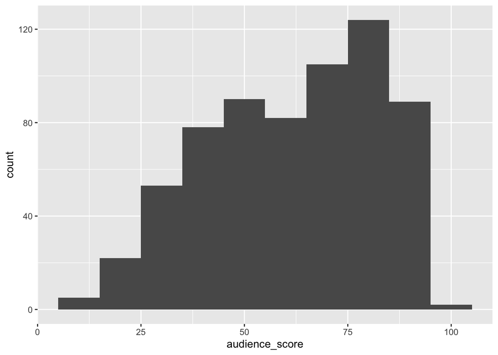

```r
ggplot(data = movies_int,aes(x=audience_score))+geom_histogram(binwidth = 10)
```

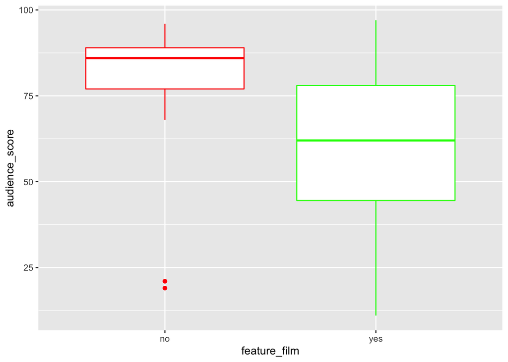

```r
ggplot(data = movies_int, mapping = aes(x=feature_film,y=audience_score))+geom_boxplot(col=c("red","green"))
```

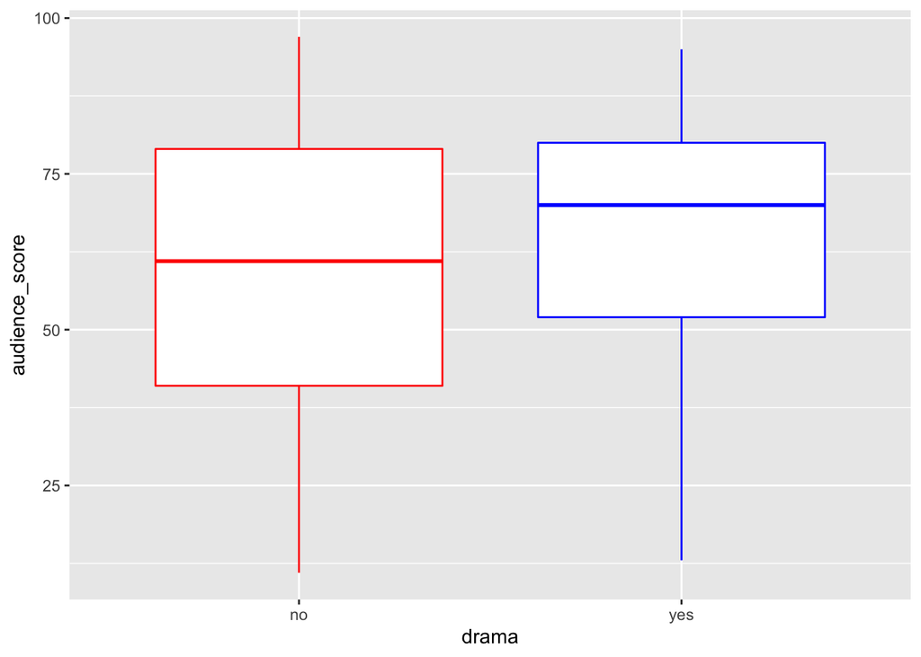

```r
# the second graph illustrate the audience of the most feature film is lower than non feature film
ggplot( data = movies_int, mapping = aes(x = drama , y = audience_score )) + geom_boxplot( col= c("red","blue"))
```

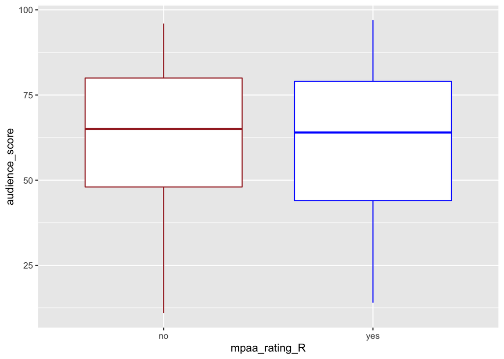

```r
ggplot( data = movies_int, mapping = aes(x = mpaa_rating_R , y = audience_score )) + geom_boxplot( col= c("brown","blue"))
```

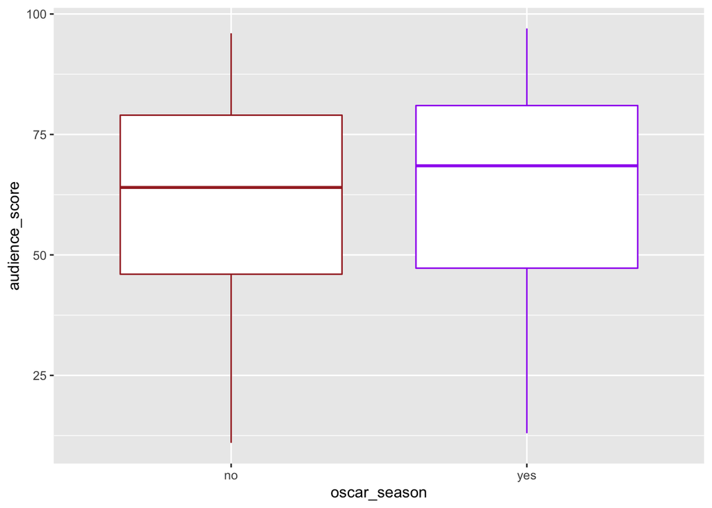

```r
ggplot( data = movies_int, mapping = aes(x = oscar_season , y = audience_score )) + geom_boxplot( col= c("brown","purple"))
```

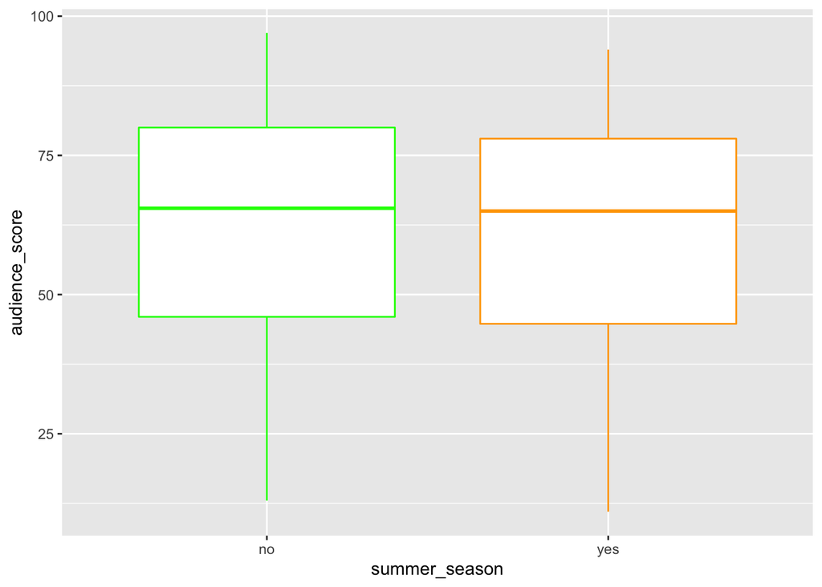

```r
ggplot( data = movies_int, mapping = aes(x = summer_season , y = audience_score )) + geom_boxplot( col=
c("green","orange"))
```

```r
# We can not see that there is apparent difference in other graphs.
```

## Part 4: Modeling

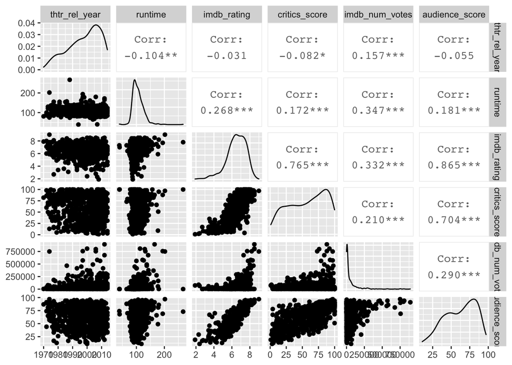

```r
# Exclude observations with missing values in the data set
ggpairs(data = movies_int,
        columns = c("thtr_rel_year","runtime","imdb_rating","critics_score","imdb_num_votes","audience_score"),progress = FALSE)
```

```r
#Bayesian Model Averaging considers all possible models using the pre-selected predictors, allowing selection of a model with consideration of uncertainty. The determination and analysis for BMA, with this amount of models and data, is not too long. Thereofore, BMA will be performed, as opposed to elimination of variables via a criterion like BIC
bma_score <- bas.lm( audience_score ~ . - critics_score - audience_score, data = movies_int,
                   prior = "ZS-null",
                   modelprior = uniform())
summary(bma_score)
```

```
##                     P(B != 0 | Y)  model 1     model 2     model 3     model 4
## Intercept              1.00000000   1.0000   1.0000000   1.0000000   1.0000000
## feature_filmyes        0.09582396   0.0000   0.0000000   0.0000000   0.0000000
## dramayes               0.04816887   0.0000   0.0000000   0.0000000   0.0000000
## runtime                0.53333008   1.0000   0.0000000   1.0000000   1.0000000
## mpaa_rating_Ryes       0.21341576   0.0000   0.0000000   1.0000000   0.0000000
## thtr_rel_year          0.12541650   0.0000   0.0000000   0.0000000   0.0000000
## oscar_seasonyes        0.07758282   0.0000   0.0000000   0.0000000   0.0000000
## summer_seasonyes       0.10306895   0.0000   0.0000000   0.0000000   0.0000000
## imdb_rating            1.00000000   1.0000   1.0000000   1.0000000   1.0000000
## imdb_num_votes         0.05210576   0.0000   0.0000000   0.0000000   0.0000000
## best_pic_nomyes        0.16588823   0.0000   0.0000000   0.0000000   1.0000000
## best_pic_winyes        0.03958509   0.0000   0.0000000   0.0000000   0.0000000
## best_actor_winyes      0.12925735   0.0000   0.0000000   0.0000000   0.0000000
## best_actress_winyes    0.12283259   0.0000   0.0000000   0.0000000   0.0000000
## best_dir_winyes        0.05378638   0.0000   0.0000000   0.0000000   0.0000000
## top200_boxyes          0.05104728   0.0000   0.0000000   0.0000000   0.0000000
## BF                             NA   1.0000   0.8957768   0.2560951   0.2286516
## PostProbs                      NA   0.1486   0.1331000   0.0381000   0.0340000
## R2                             NA   0.7509   0.7481000   0.7524000   0.7523000
## dim                            NA   3.0000   2.0000000   4.0000000   4.0000000
## logmarg                        NA 441.8905 441.7804447 440.5283023 440.4149528
##                         model 5
## Intercept             1.0000000
## feature_filmyes       0.0000000
## dramayes              0.0000000
## runtime               0.0000000
## mpaa_rating_Ryes      1.0000000
## thtr_rel_year         0.0000000
## oscar_seasonyes       0.0000000
## summer_seasonyes      0.0000000
## imdb_rating           1.0000000
## imdb_num_votes        0.0000000
## best_pic_nomyes       0.0000000
## best_pic_winyes       0.0000000
## best_actor_winyes     0.0000000
## best_actress_winyes   0.0000000
## best_dir_winyes       0.0000000
## top200_boxyes         0.0000000
## BF                    0.2109958
## PostProbs             0.0314000
## R2                    0.7497000
## dim                   3.0000000
## logmarg             440.3345915
```

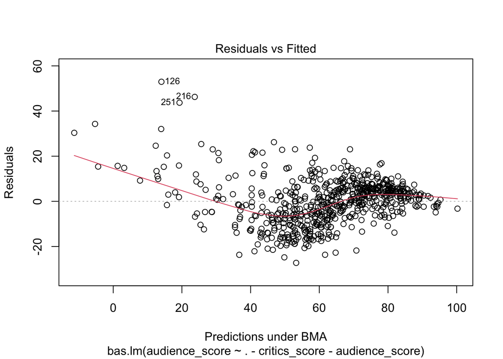

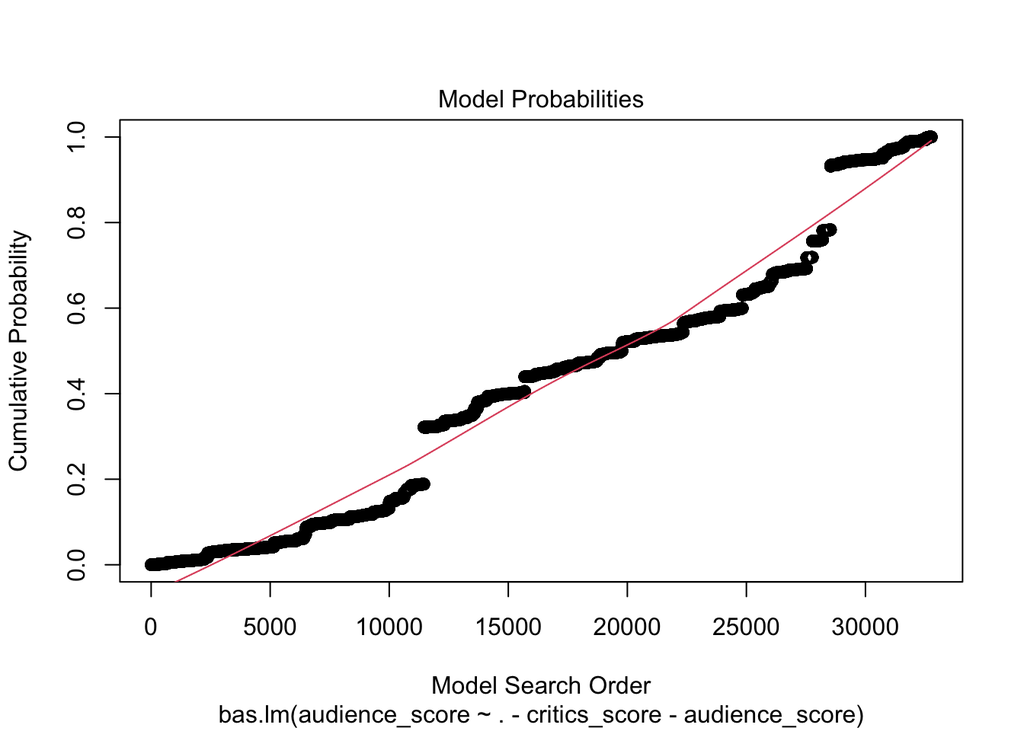

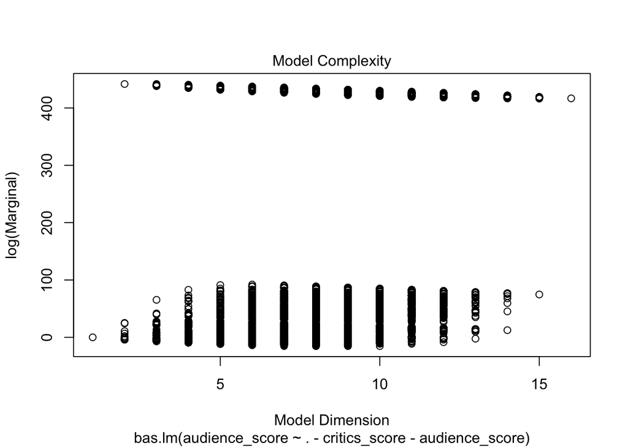

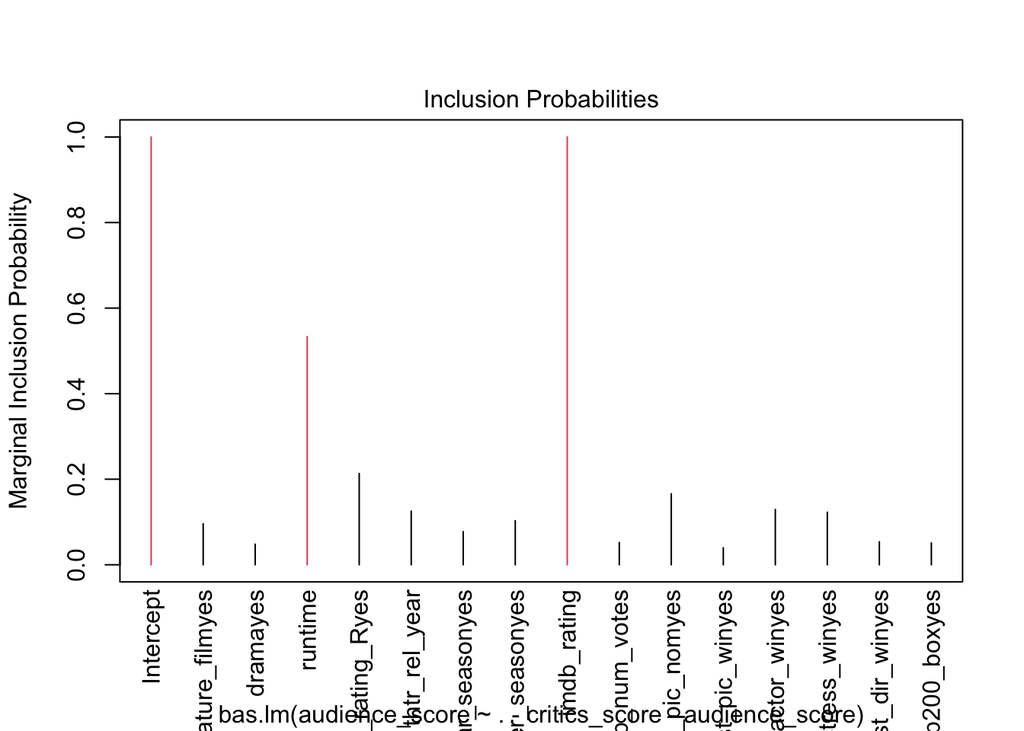

```r
BMA_pred_audience_score <- predict(bma_score, estimator = "BMA", se.fit = TRUE)
#There is a plot of the residuals vs. fitted (predicted) values
m_bma_score_aug <- movies_int %>%
  dplyr::select(audience_score) %>%
  mutate(fitted = BMA_pred_audience_score$fit,
         resid  = audience_score - fitted,
         std_resid = resid/sd(resid) )       # standardised residuals
#This is the plot.
plot(bma_score)
```

## Part 5: Prediction

There is a Chinese movie called “Crouching tigger , Hidden Dragon”

```r
# Create a new data frame.
# We can find this information from the internet.
movies_a <- movies_int
movies_a$feature_film[600] <- "no"
movies_a$drama[600] <- "yes"
movies_a$runtime[600] <- 120
movies_a$mpaa_rating_R[600] <- "no"
movies_a$oscar_season[600] <- "yes"
movies_a$summer_season[600] <- "no"
movies_a$imdb_rating[600] <- 6.0
movies_a$thtr_rel_year[600] <- 2001
movies_a$best_pic_nom[600] <- "yes"
movies_a$best_pic_win[600] <- "yes"
movies_a$best_actor_win[600] <- "no"
movies_a$best_actress_win[600] <- "no"
movies_a$best_dir_win[600] <- "no"
movies_a$top200_box[600] <- "no"
movies_a$critics_score[600] <- 87
movies_a$audience_score[600] <- 90
movies_a <- movies_a[600,]
# prediction using BMA model and new data
BMA_new_pred_audience_score <- predict(object = bma_score, newdata = movies_a,
                                       se.fit = TRUE, estimator = "BMA")
confint(BMA_new_pred_audience_score)
```

```
##          2.5%   97.5%     pred
## [1,] 35.50908 75.7795 54.93863
## attr(,"Probability")
## [1] 0.95
## attr(,"class")
## [1] "confint.bas"
```

The predicted score is 55%.

## Part 6: Conclusion

The data used for modelling included characteristics that are not ideal for the modelling within scope of this course. For example:there were categorical variables with low counts of one of their levels there were outliers signs of association among the categorical explanatory variables deviation from normal distributions, including cases of extreme skew and flat middle of the range non-linearilty in the relationships between most predictors and the reponse variable non-constant variance in the residuals.